# IMPORTS

```python
import pandas as pd
import numpy as np
import matplotlib as mpl
import matplotlib.pyplot as plt
import seaborn as sns
import datetime as dt
import sklearn

from sklearn.impute import KNNImputer
from sklearn.preprocessing import MinMaxScaler
from sklearn.linear_model import LinearRegression

import warnings
warnings.simplefilter(action='ignore', category=FutureWarning)
pd.set_option('display.max_columns', None)
```

# First Dataset

The first dataset, TRAIN, contains annual information on the results of the La Viña cooperative's campaigns, showing the following variables:

```
• CAMPAÑA: Year of the campaign.
• ID_FINCA: Farm identifier.
• ID_ZONA: Identifier of a zone with a common soil typology.
• ID_ESTACION: Identifier of meteorological station.
• ALTITUD: Average height of the farm above sea level in meters.
• VARIEDAD: Grape variety code of the grape grown on the estate.
• MODO: Code of the mode of cultivation.
• TIPO: Type of crop within the variety.
• COLOR: Grape color identifier.
• SUPERFICIE: Area in hectares occupied by the farm.
• PRODUCCION: Production in kg. Obtained in the campaign.
```

## DATA PREPARATION

Import and brief exploration of the dataset

```python
TRAIN = pd.read_csv('./Datos_Originales/UH_2023_TRAIN.txt',delimiter = '|', na_values = 'NA', encoding='UTF-8')
```

```python
TRAIN.head()
```

|  | CAMPAÑA | ID_FINCA | ID_ZONA | ID_ESTACION | ALTITUD | VARIEDAD | MODO | TIPO | COLOR | SUPERFICIE | PRODUCCION |
| --- | --- | --- | --- | --- | --- | --- | --- | --- | --- | --- | --- |
| 0 | 14 | 76953 | 515 | 4 | 660 | 26 | 2 | 0 | 1 | 0.0 | 22215.0 |
| 1 | 14 | 84318 | 515 | 4 | 660 | 26 | 2 | 0 | 1 | 0.0 | 22215.0 |
| 2 | 14 | 85579 | 340 | 4 | 520 | 32 | 2 | 0 | 1 | 0.0 | 20978.0 |
| 3 | 14 | 69671 | 340 | 4 | 520 | 32 | 2 | 0 | 1 | 0.0 | 40722.0 |
| 4 | 14 | 14001 | 852 | 14 | NaN | 81 | 1 | 0 | 1 | 0.0 | 14126.0 |

```python
TRAIN.info()
```

```
<class 'pandas.core.frame.DataFrame'>
RangeIndex: 9601 entries, 0 to 9600
Data columns (total 11 columns):
 #   Column       Non-Null Count  Dtype
---  ------       --------------  -----
 0   CAMPAÑA      9601 non-null   int64
 1   ID_FINCA     9601 non-null   int64
 2   ID_ZONA      9601 non-null   int64
 3   ID_ESTACION  9601 non-null   int64
 4   ALTITUD      9547 non-null   object
 5   VARIEDAD     9601 non-null   int64
 6   MODO         9601 non-null   int64
 7   TIPO         9601 non-null   int64
 8   COLOR        9601 non-null   int64
 9   SUPERFICIE   9601 non-null   float64
 10  PRODUCCION   8526 non-null   float64
dtypes: float64(2), int64(8), object(1)
memory usage: 825.2+ KB
```

```python
def formatoAltitud(row):
    if type(row['ALTITUD']) == str:
        range = [float(a) for a in row['ALTITUD'].split('-')]
        if len(range) > 2:
            return np.mean(range)
        else:
            return range[0]
    else:
        return row['ALTITUD']

TRAIN['ALTITUD'] = TRAIN.apply(formatoAltitud, axis=1)
```

Excluding the identifiers and campaign ("CAMPAÑA") we will see more information about the rest of the variables.

```python
TRAIN[[i for i in TRAIN if i not in ['CAMPAÑA', 'ID_FINCA', 'ID_ZONA', 'ID_ESTACION']]].describe()
```

|  | ALTITUD | VARIEDAD | MODO | TIPO | COLOR | SUPERFICIE | PRODUCCION |
| --- | --- | --- | --- | --- | --- | --- | --- |
| count | 9547.000000 | 9601.000000 | 9601.000000 | 9601.000000 | 9601.00000 | 9601.000000 | 8526.000000 |
| mean | 563.313606 | 45.487658 | 1.509426 | 0.012290 | 0.84335 | 0.697517 | 9209.190958 |
| std | 75.795142 | 23.814567 | 0.499937 | 0.110184 | 0.36349 | 1.786268 | 13268.812623 |
| min | 370.000000 | 4.000000 | 1.000000 | 0.000000 | 0.00000 | 0.000000 | 0.718000 |
| 25% | 480.000000 | 17.000000 | 1.000000 | 0.000000 | 1.00000 | 0.000000 | 1940.000000 |
| 50% | 600.000000 | 52.000000 | 2.000000 | 0.000000 | 1.00000 | 0.000000 | 4620.000000 |
| 75% | 625.000000 | 59.000000 | 2.000000 | 0.000000 | 1.00000 | 0.561900 | 11137.500000 |
| max | 820.000000 | 94.000000 | 2.000000 | 1.000000 | 1.00000 | 26.850000 | 177520.000000 |

It can be seen that the surface ("SUPERFICIE") has at least 0, since this is impossible we will replace the values that are at 0 by np.nan, to deal with them later.

```python
TRAIN['SUPERFICIE'].replace(0.0, np.nan, inplace = True)
TRAIN[[i for i in TRAIN if i not in ['CAMPAÑA', 'ID_FINCA', 'ID_ZONA', 'ID_ESTACION']]].describe()
```

|  | ALTITUD | VARIEDAD | MODO | TIPO | COLOR | SUPERFICIE | PRODUCCION |
| --- | --- | --- | --- | --- | --- | --- | --- |
| count | 9547.000000 | 9601.000000 | 9601.000000 | 9601.000000 | 9601.00000 | 3083.000000 | 8526.000000 |
| mean | 563.313606 | 45.487658 | 1.509426 | 0.012290 | 0.84335 | 2.172191 | 9209.190958 |
| std | 75.795142 | 23.814567 | 0.499937 | 0.110184 | 0.36349 | 2.595080 | 13268.812623 |
| min | 370.000000 | 4.000000 | 1.000000 | 0.000000 | 0.00000 | 0.000720 | 0.718000 |
| 25% | 480.000000 | 17.000000 | 1.000000 | 0.000000 | 1.00000 | 0.630000 | 1940.000000 |
| 50% | 600.000000 | 52.000000 | 2.000000 | 0.000000 | 1.00000 | 1.341600 | 4620.000000 |
| 75% | 625.000000 | 59.000000 | 2.000000 | 0.000000 | 1.00000 | 2.709000 | 11137.500000 |
| max | 820.000000 | 94.000000 | 2.000000 | 1.000000 | 1.00000 | 26.850000 | 177520.000000 |

## EDA

```python
columns_with_missing_data_TRAIN = TRAIN.isnull().sum()[TRAIN.isnull().sum() > 0].index
TRAIN.groupby('CAMPAÑA')[columns_with_missing_data_TRAIN].apply(lambda x: x.isnull().sum())
```

| CAMPAÑA | ALTITUD | SUPERFICIE | PRODUCCION |
| --- | --- | --- | --- |
| 14 | 9 | 1148 | 0 |
| 15 | 9 | 1116 | 0 |
| 16 | 3 | 1079 | 0 |
| 17 | 4 | 1017 | 0 |
| 18 | 6 | 1061 | 0 |
| 19 | 6 | 1055 | 0 |
| 20 | 6 | 13 | 0 |
| 21 | 6 | 20 | 0 |
| 22 | 5 | 9 | 1075 |

We can see the existence of missing data in the variables "ALTITUD", "SUPERFICIE" and "PRODUCCION", this last one is our class variable to predict so the missing data of the year 2022 are not taken into account since they are the ones we need to predict, although except for "PRODUCCION" there are also missing values in "ALTITUD" and "SUPERFICIE" that year so we cannot remove that part of the dataset.

Let's take a more graphic look at this data.

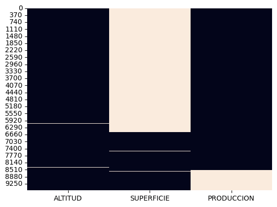

```python
sns.heatmap(TRAIN[columns_with_missing_data_TRAIN].isnull(), cbar=False);
```

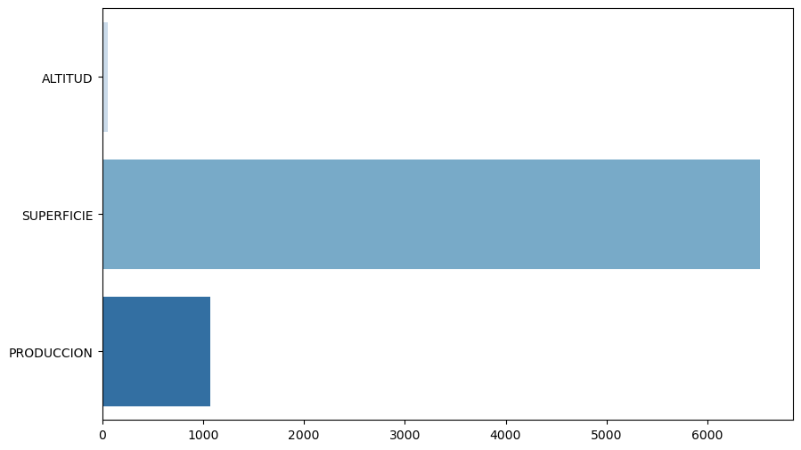

```python
plt.figure(figsize=(10, 6))
sns.barplot(x=TRAIN[columns_with_missing_data_TRAIN].isnull().sum().values, y=TRAIN[columns_with_missing_data_TRAIN].isnull().sum().index, orient = 'h', palette = 'Blues')
plt.show();
```

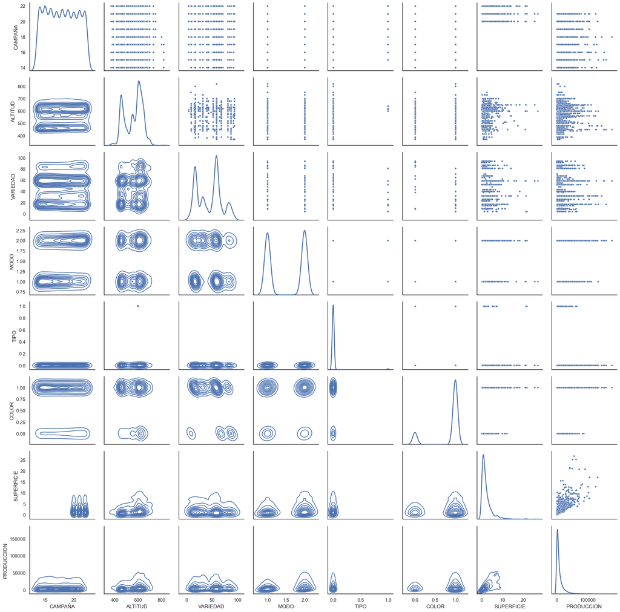

```python
sns.set_theme(style="white")

columns = [col for col in TRAIN.columns if 'ID' not in col]

g = sns.PairGrid(TRAIN[columns], diag_sharey=False)
g.map_upper(sns.scatterplot, s=15)
g.map_lower(sns.kdeplot)
g.map_diag(sns.kdeplot, lw=2)
plt.show()
```

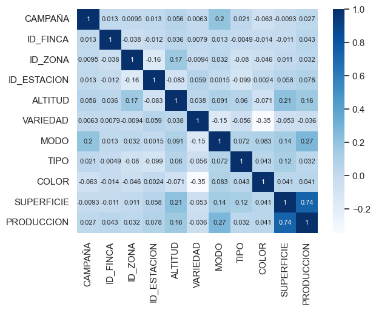

```python
correlation_matrix = TRAIN.corr()
sns.heatmap(correlation_matrix, annot=True, cmap='Blues', annot_kws={"size": 8})
plt.show()
```

As expected, thanks to the correlation matrix, we can see that production is highly correlated with crop area.

Next, we visualize the distribution of all the variables and equally excluding the identifiers, with histplots to see the distribution of both continuous and categorical variables where we see that the binary variable MODE is more balanced than the binary variables TYPE and COLOR where a clear imbalance can be observed.

As for the variables VARIETY and ALTITUDE we can see that there are certain cases that are more common than the rest.

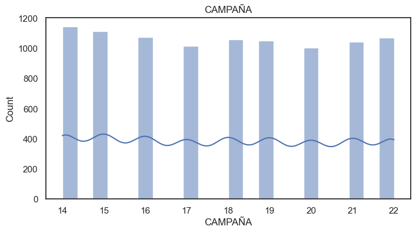

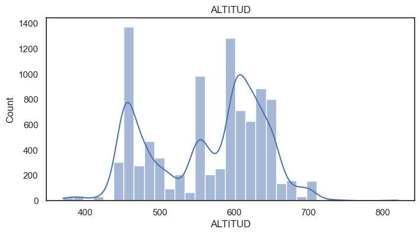

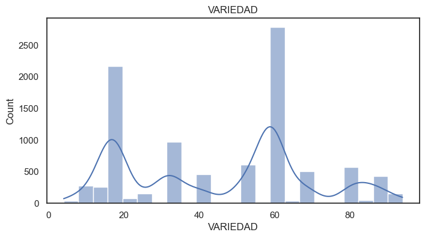

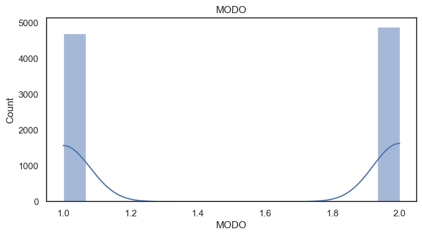

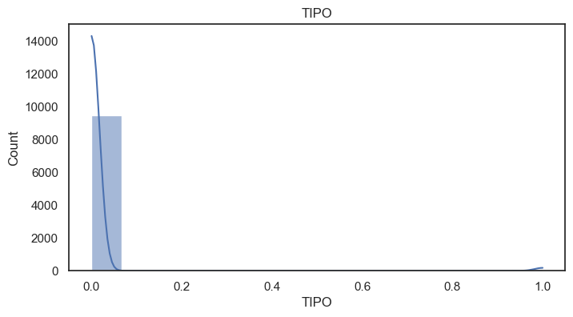

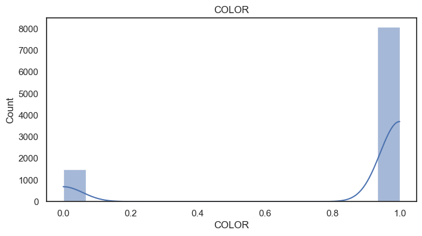

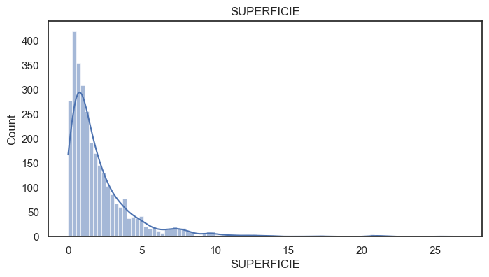

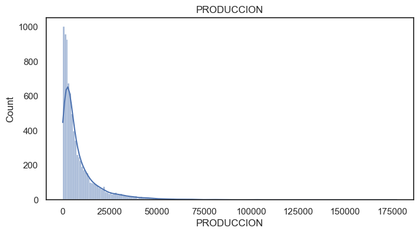

```python
columns = [col for col in TRAIN.columns if 'ID' not in col]

for col in columns:
    plt.figure(figsize=(8,4))
    sns.histplot(x=TRAIN[col], kde=True)
    plt.title(col)
    plt.show()
```

We also used bar charts with the categorical variables by seasons to observe a clear imbalance in some of them, as in the case of "COLOR" and "TIPO", and we also observed how the trend of "MODO" changes as the seasons progress, i.e., how initially mode 1 was mostly used, but mode 2 is increasing until in the last seasons mode 2 is the most used. Finally, it can also be seen that variety 59 is the most cultivated variety in all seasons.

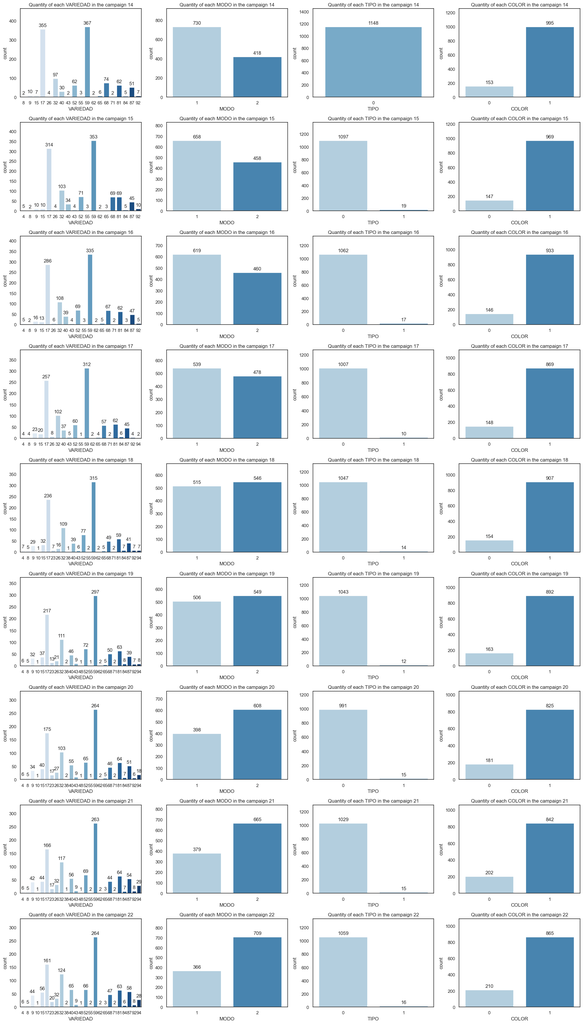

```python
columns = ['VARIEDAD', 'MODO', 'TIPO', 'COLOR']
campañas = TRAIN.CAMPAÑA.unique()
fig, axes = plt.subplots(nrows=len(campañas), ncols=len(columns), figsize=(20, 35))


for i_row, (axes_row, variable) in enumerate(zip(axes, campañas)):
    for ax, stat in zip(axes_row, columns):
        sns.countplot(data=TRAIN[TRAIN['CAMPAÑA'] == variable], x=stat, ax = ax, palette = 'Blues')
        ax.set_title(f"Quantity of each {stat} in the campaign {variable}")
        ax.set_ylim(0, ax.get_ylim()[1] * 1.2)

        for p in ax.patches:
            ax.annotate(format(p.get_height(), '.0f'),
                        (p.get_x() + p.get_width() / 2., p.get_height()),
                        ha='center', va='center',
                        xytext=(0, 9),
                        textcoords='offset points')

plt.tight_layout()
plt.show()
```

To finish with the visualization of this data set we use lineplots visualizing the production along the campaigns. We generate a graph depending on each of the variables that we have visualized before, where we can clearly see the unbalance of the variables and how the production is higher in the majority classes of those variables. Finally, we represent the production along the campaigns in a general manner, showing how there was a drop in production in season 17 and a large increase in season 18.

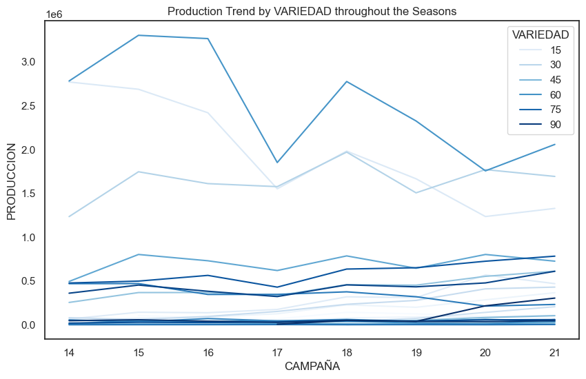

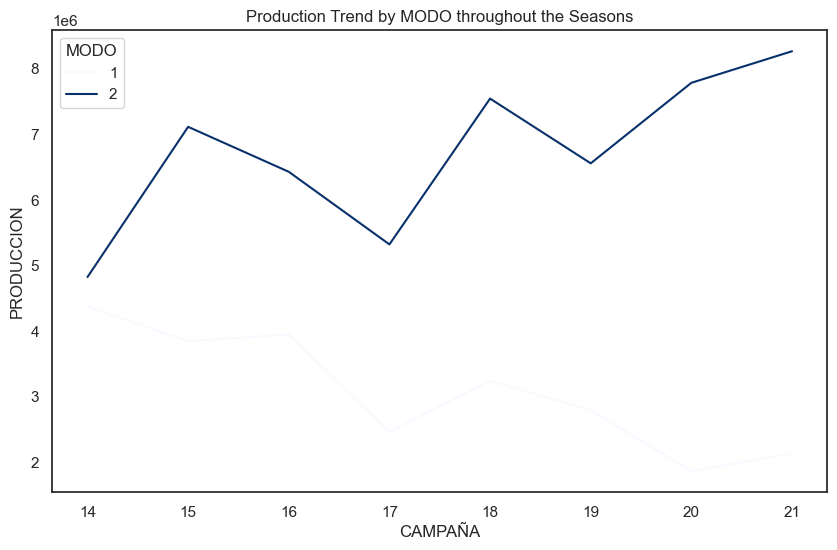

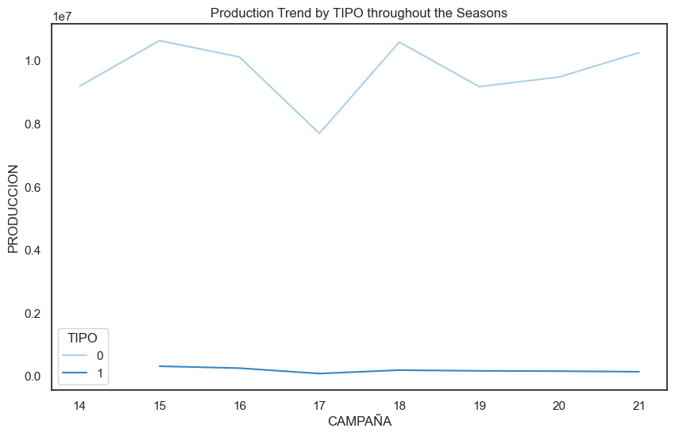

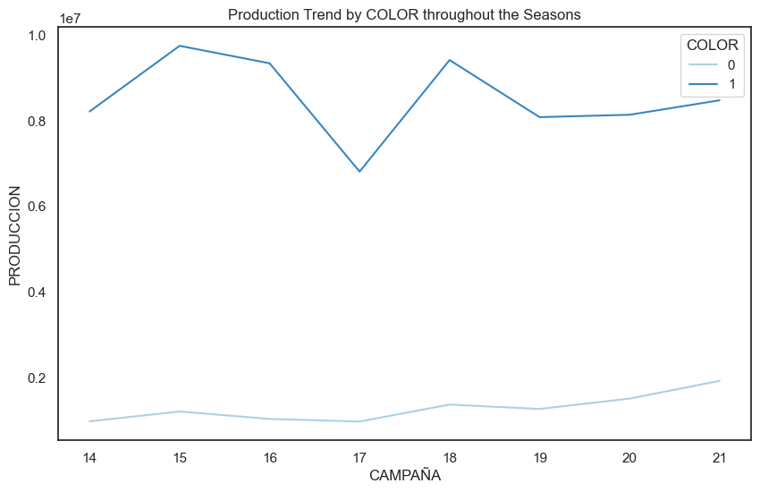

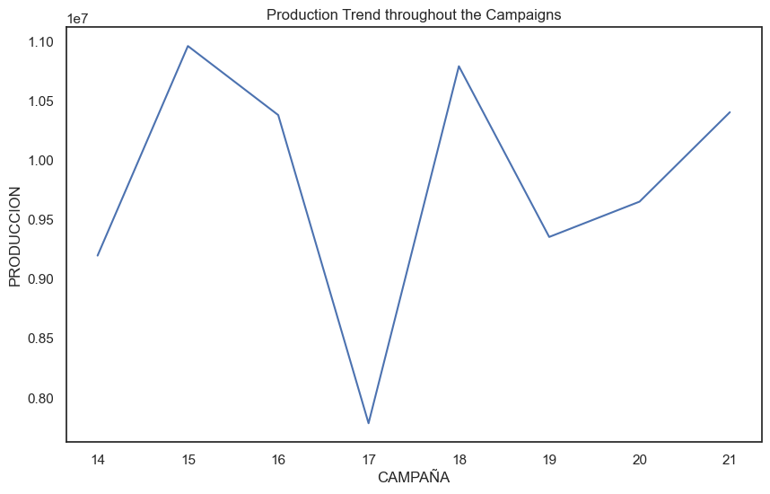

```python
columns = ['VARIEDAD', 'MODO', 'TIPO', 'COLOR']

for col in columns:
    grouped = TRAIN.groupby(['CAMPAÑA',col])['PRODUCCION'].sum().reset_index()
    grouped = grouped[grouped['CAMPAÑA']!=22]
    plt.figure(figsize=(10, 6))
    sns.lineplot(data=grouped, x='CAMPAÑA', y='PRODUCCION',hue=col, palette = 'Blues')
    plt.title(f'Production Trend by {col} throughout the Seasons')
    plt.show()


grouped = TRAIN.groupby(['CAMPAÑA'])['PRODUCCION'].sum().reset_index()
grouped = grouped[grouped['CAMPAÑA']!=22]
plt.figure(figsize=(10, 6))
sns.lineplot(data=grouped, x='CAMPAÑA', y='PRODUCCION')
plt.title('Production Trend throughout the Campaigns')
plt.show()
```

## DATA PREPROCESSING

```python
TRAIN_MISS = TRAIN.groupby('CAMPAÑA')[columns_with_missing_data_TRAIN].apply(lambda x: x.isnull().sum())
for i, row in TRAIN_MISS.iterrows():
    TRAIN_MISS.loc[i,'TAMAÑO'] = len(TRAIN[TRAIN.CAMPAÑA == i])

TRAIN_MISS
```

| CAMPAÑA | ALTITUD | SUPERFICIE | PRODUCCION | TAMAÑO |
| --- | --- | --- | --- | --- |
| 14 | 9 | 1148 | 0 | 1148.0 |
| 15 | 9 | 1116 | 0 | 1116.0 |
| 16 | 3 | 1079 | 0 | 1079.0 |
| 17 | 4 | 1017 | 0 | 1017.0 |
| 18 | 6 | 1061 | 0 | 1061.0 |
| 19 | 6 | 1055 | 0 | 1055.0 |
| 20 | 6 | 13 | 0 | 1006.0 |
| 21 | 6 | 20 | 0 | 1044.0 |
| 22 | 5 | 9 | 1075 | 1075.0 |

We are going to start imputing the missing values of the variable "ALTITUD", for this we are going to go campaign by campaign imputing the missing values with the median of altitudes of the same station, in case we do not have the data of a station, that is to say, that station only has instances with the variable "ALTITUD" unknown, the median of the complete campaign will be used.

```python
grupos = TRAIN.groupby('CAMPAÑA')

dataframes = {}
dataframes_ALTITUD = {}

for campaña, grupo in grupos:
    dataframes[campaña] = grupo.reset_index(level=0, drop=True)

for campaña, df in dataframes.items():
    df_ALTITUD = df.copy(deep = True)
    altitud = df_ALTITUD.groupby('ID_ESTACION').agg({'ALTITUD':np.nanmedian}).reset_index()
    for i, row in df_ALTITUD.iterrows():
        if pd.isna(row['ALTITUD']):
            alt = altitud[altitud['ID_ESTACION']==row['ID_ESTACION']]['ALTITUD'].values
            if np.isnan(alt[0]):
                df_ALTITUD.loc[i, 'ALTITUD'] = df_ALTITUD.agg({'ALTITUD':np.nanmedian}).values[0]
            else:
                df_ALTITUD.loc[i, 'ALTITUD'] = alt[0]
        else:
            pass
        dataframes_ALTITUD[campaña] = df_ALTITUD

TRAIN_ALTITUD = pd.concat(dataframes_ALTITUD.values(), ignore_index=True)
```

```python
TRAIN_MISS = TRAIN_ALTITUD.groupby('CAMPAÑA')[columns_with_missing_data_TRAIN].apply(lambda x: x.isnull().sum())
for i, row in TRAIN_MISS.iterrows():
    TRAIN_MISS.loc[i,'TAMAÑO'] = len(TRAIN[TRAIN.CAMPAÑA == i])

TRAIN_MISS
```

| CAMPAÑA | ALTITUD | SUPERFICIE | PRODUCCION | TAMAÑO |
| --- | --- | --- | --- | --- |
| 14 | 0 | 1148 | 0 | 1148.0 |
| 15 | 0 | 1116 | 0 | 1116.0 |
| 16 | 0 | 1079 | 0 | 1079.0 |
| 17 | 0 | 1017 | 0 | 1017.0 |
| 18 | 0 | 1061 | 0 | 1061.0 |
| 19 | 0 | 1055 | 0 | 1055.0 |
| 20 | 0 | 13 | 0 | 1006.0 |
| 21 | 0 | 20 | 0 | 1044.0 |
| 22 | 0 | 9 | 1075 | 1075.0 |

Now we are going to continue imputing the variable "SUPERFICIE", but we have the problem that for campaigns 14 to 19 we do not have any data, so we must commit data leakage and use information from the "future" to predict the "past".

For this we are going to use the information we have for the variable "SUPERFICIE" in our complete data set, taking into account the variables "VARIEDAD", "MODO", "TIPO", "COLOR" and "ID_FINCA".

```python
data_superficie = TRAIN_ALTITUD[['ID_FINCA', 'VARIEDAD', 'MODO', 'TIPO', 'COLOR', 'SUPERFICIE']].sort_values(['ID_FINCA', 'VARIEDAD', 'MODO', 'TIPO', 'COLOR']).dropna().drop_duplicates().reset_index(drop=True)
data_superficie
```

|  | ID_FINCA | VARIEDAD | MODO | TIPO | COLOR | SUPERFICIE |
| --- | --- | --- | --- | --- | --- | --- |
| 0 | 200 | 59 | 1 | 0 | 1 | 0.3700 |
| 1 | 439 | 9 | 2 | 0 | 0 | 1.0800 |
| 2 | 447 | 40 | 2 | 0 | 1 | 0.4694 |
| 3 | 523 | 32 | 2 | 0 | 1 | 0.6478 |
| 4 | 702 | 59 | 2 | 0 | 1 | 1.1331 |
| ... | ... | ... | ... | ... | ... | ... |
| 1475 | 99377 | 52 | 2 | 0 | 1 | 0.6500 |
| 1476 | 99693 | 81 | 1 | 0 | 1 | 6.3500 |
| 1477 | 99693 | 81 | 1 | 0 | 1 | 6.3397 |
| 1478 | 99793 | 52 | 2 | 0 | 1 | 0.1326 |
| 1479 | 99793 | 87 | 2 | 0 | 0 | 0.0189 |

1480 rows × 6 columns

```python
TRAIN_SUPERFICIE = TRAIN_ALTITUD.copy(deep = True)


for i, row in TRAIN_SUPERFICIE.iterrows():
    if pd.isna(row['SUPERFICIE']):

########################################################################################
#ALL VALUES ARE THE SAME (SAME ID_FINCA)
########################################################################################
        valores = list(data_superficie[(row['ID_FINCA'] == data_superficie['ID_FINCA']) & (row['VARIEDAD'] == data_superficie['VARIEDAD']) & (row['MODO'] == data_superficie['MODO']) & (row['TIPO'] == data_superficie['TIPO']) & (row['COLOR'] == data_superficie['COLOR'])]['SUPERFICIE'])
        if valores:
            if len(valores) > 1:
                TRAIN_SUPERFICIE.loc[i,'SUPERFICIE'] = np.mean(valores)

            else:
                TRAIN_SUPERFICIE.loc[i,'SUPERFICIE'] = valores[0]

########################################################################################
#ALL VALUES EXCEPT ONE ARE EQUAL (SAME ID_FINCA)
########################################################################################
        else:
            valores0 = list(data_superficie[(row['ID_FINCA'] == data_superficie['ID_FINCA']) & (row['VARIEDAD'] == data_superficie['VARIEDAD']) & (row['TIPO'] == data_superficie['TIPO']) & (row['COLOR'] == data_superficie['COLOR'])]['SUPERFICIE'])
            if valores0:
                if len(valores0) > 1:
                    TRAIN_SUPERFICIE.loc[i,'SUPERFICIE'] = np.mean(valores0)

                else:
                    TRAIN_SUPERFICIE.loc[i,'SUPERFICIE'] = valores0[0]

########################################################################################
#TWO VALUES ARE EQUAL (SAME ID_FINCA)
########################################################################################
            else:
                valores2 = list(data_superficie[(row['ID_FINCA'] == data_superficie['ID_FINCA']) & (row['TIPO'] == data_superficie['TIPO']) & (row['COLOR'] == data_superficie['COLOR'])]['SUPERFICIE'])
                if valores2:
                    if len(valores2) > 1:
                        TRAIN_SUPERFICIE.loc[i,'SUPERFICIE'] = np.mean(valores2)
                    else:
                        TRAIN_SUPERFICIE.loc[i,'SUPERFICIE'] = valores2[0]
                else:
                    valores2 = list(data_superficie[(row['ID_FINCA'] == data_superficie['ID_FINCA']) & (row['TIPO'] == data_superficie['TIPO']) & (row['MODO'] == data_superficie['MODO'])]['SUPERFICIE'])
                    if valores2:
                        if len(valores2) > 1:
                            TRAIN_SUPERFICIE.loc[i,'SUPERFICIE'] = np.mean(valores2)
                        else:
                            TRAIN_SUPERFICIE.loc[i,'SUPERFICIE'] = valores2[0]
                    else:
                        valores2 = list(data_superficie[(row['ID_FINCA'] == data_superficie['ID_FINCA']) & (row['COLOR'] == data_superficie['COLOR']) & (row['MODO'] == data_superficie['MODO'])]['SUPERFICIE'])
                        if valores2:
                            if len(valores2) > 1:
                                TRAIN_SUPERFICIE.loc[i,'SUPERFICIE'] = np.mean(valores2)
                            else:
                                TRAIN_SUPERFICIE.loc[i,'SUPERFICIE'] = valores2[0]

########################################################################################
#ONE VALUE IS EQUAL (SAME ID_FINCA)
########################################################################################
                        else:
                            valores3 = list(data_superficie[(row['ID_FINCA'] == data_superficie['ID_FINCA']) & (row['TIPO'] == data_superficie['TIPO'])]['SUPERFICIE'])
                            if valores3:
                                if len(valores3) > 1:
                                    TRAIN_SUPERFICIE.loc[i,'SUPERFICIE'] = np.mean(valores3)
                                else:
                                    TRAIN_SUPERFICIE.loc[i,'SUPERFICIE'] = valores3[0]
                            else:
                                valores3 = list(data_superficie[(row['ID_FINCA'] == data_superficie['ID_FINCA']) & (row['COLOR'] == data_superficie['COLOR'])]['SUPERFICIE'])
                                if valores3:
                                    if len(valores3) > 1:
                                        TRAIN_SUPERFICIE.loc[i,'SUPERFICIE'] = np.mean(valores3)
                                    else:
                                        TRAIN_SUPERFICIE.loc[i,'SUPERFICIE'] = valores3[0]

########################################################################################
#NO VALUES ARE EQUAL (SAME ID_FINCA)
########################################################################################
                                else:
                                    valores4 = list(data_superficie[(row['ID_FINCA'] == data_superficie['ID_FINCA'])]['SUPERFICIE'])
                                    if valores4:
                                        if len(valores4) > 1:
                                            TRAIN_SUPERFICIE.loc[i,'SUPERFICIE'] = np.mean(valores4)
                                        else:
                                            TRAIN_SUPERFICIE.loc[i,'SUPERFICIE'] = valores4[0]
########################################################################################
#NO MATCH WITH THE SAME ID_FINCA
########################################################################################
                                    else:
                                        pass
    else:
        pass
```

```python
TRAIN_SUPERFICIE.groupby('CAMPAÑA')[columns_with_missing_data_TRAIN].apply(lambda x: x.isnull().sum())
```

| CAMPAÑA | ALTITUD | SUPERFICIE | PRODUCCION |
| --- | --- | --- | --- |
| 14 | 0 | 288 | 0 |
| 15 | 0 | 230 | 0 |
| 16 | 0 | 167 | 0 |
| 17 | 0 | 116 | 0 |
| 18 | 0 | 82 | 0 |
| 19 | 0 | 57 | 0 |
| 20 | 0 | 4 | 0 |
| 21 | 0 | 3 | 0 |
| 22 | 0 | 2 | 1075 |

Thanks to this imputation we can see that the missing values in "SUPERFICIE" have been considerably reduced.

For the remaining missing data of the variable "SURFACE" we are going to try different imputation methods to see which one suits us best.

- Random imputation
- Imputation of the mean
- Imputation of the mode
- Imputation of the median
- Deterministic Regression Imputation
- Stochastic Regression Imputation

Random imputation

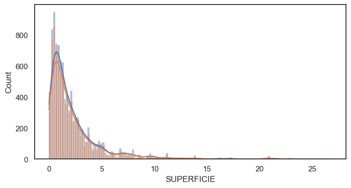

```python
grupos = TRAIN_SUPERFICIE.groupby('CAMPAÑA')

dataframes = {}
dataframes_final_rand = {}

for campaña, grupo in grupos:
    dataframes[campaña] = grupo.reset_index(level=0, drop=True)

for campaña, df in dataframes.items():
    datos_train_regresionR = df.copy(deep=True)

    number_missing = datos_train_regresionR['SUPERFICIE'].isnull().sum()
    observed_values = datos_train_regresionR.loc[datos_train_regresionR['SUPERFICIE'].notnull(), 'SUPERFICIE']
    datos_train_regresionR.loc[datos_train_regresionR['SUPERFICIE'].isnull(), 'SUPERFICIE'] = np.random.choice(observed_values, number_missing, replace = True)

    dataframes_final_rand[campaña] = datos_train_regresionR

TRAIN_FINAL_RAND = pd.concat(dataframes_final_rand.values(), ignore_index=True)

plt.figure(figsize=(8,4))
sns.histplot(x=TRAIN_FINAL_RAND['SUPERFICIE'], kde=True)
sns.histplot(x=TRAIN_SUPERFICIE['SUPERFICIE'], kde=True);
```

```python
sns.heatmap(TRAIN_FINAL_RAND[['SUPERFICIE']].isnull(), cbar=False);
```

Imputation of the mean

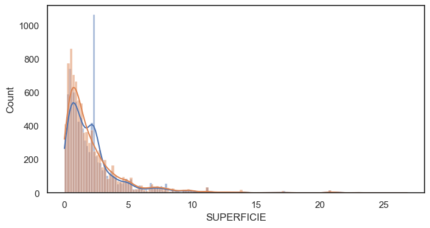

```python
grupos = TRAIN_SUPERFICIE.groupby('CAMPAÑA')

dataframes = {}
dataframes_final_mean = {}

for campaña, grupo in grupos:
    dataframes[campaña] = grupo.reset_index(level=0, drop=True)

for campaña, df in dataframes.items():
    datos_train_media = df.copy(deep=True)

    datos_train_media.loc[datos_train_media['SUPERFICIE'].isnull(),'SUPERFICIE'] = datos_train_media.loc[datos_train_media['SUPERFICIE'].isnull() == False, 'SUPERFICIE'].mean()

    dataframes_final_mean[campaña] = datos_train_media

TRAIN_FINAL_MEAN = pd.concat(dataframes_final_mean.values(), ignore_index=True)

plt.figure(figsize=(8,4))
sns.histplot(x=TRAIN_FINAL_MEAN['SUPERFICIE'], kde=True)
sns.histplot(x=TRAIN_SUPERFICIE['SUPERFICIE'], kde=True);
```

```python
sns.heatmap(TRAIN_FINAL_MEAN[['SUPERFICIE']].isnull(), cbar=False);
```

Imputation of the mode

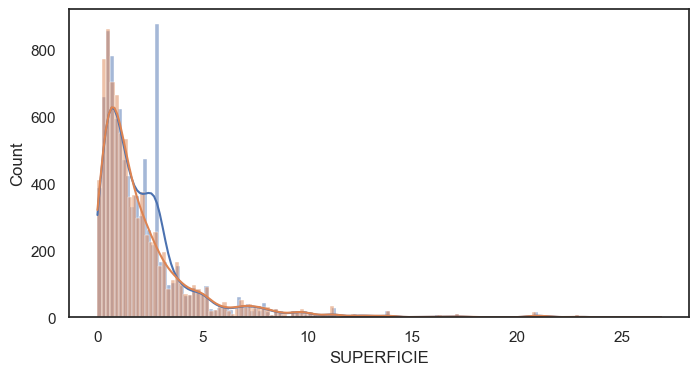

```python
grupos = TRAIN_SUPERFICIE.groupby('CAMPAÑA')

dataframes = {}
dataframes_final_moda = {}

for campaña, grupo in grupos:
    dataframes[campaña] = grupo.reset_index(level=0, drop=True)

for campaña, df in dataframes.items():
    datos_train_moda = df.copy(deep=True)

    datos_train_moda.loc[datos_train_moda['SUPERFICIE'].isnull(),'SUPERFICIE'] = datos_train_moda.loc[datos_train_moda['SUPERFICIE'].isnull() == False, 'SUPERFICIE'].mode()[0]

    dataframes_final_moda[campaña] = datos_train_moda

TRAIN_FINAL_MODE = pd.concat(dataframes_final_moda.values(), ignore_index=True)

plt.figure(figsize=(8,4))
sns.histplot(x=TRAIN_FINAL_MODE['SUPERFICIE'], kde=True)
sns.histplot(x=TRAIN_SUPERFICIE['SUPERFICIE'], kde=True);
```

```python
sns.heatmap(TRAIN_FINAL_MODE[['SUPERFICIE']].isnull(), cbar=False);
```

Imputation of the median

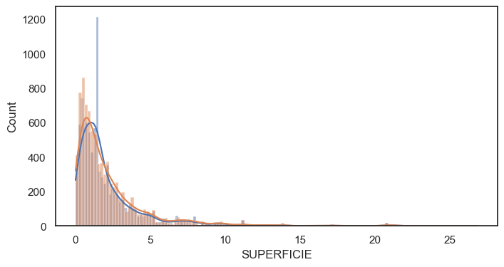

```python
grupos = TRAIN_SUPERFICIE.groupby('CAMPAÑA')

dataframes = {}
dataframes_final_mediana = {}

for campaña, grupo in grupos:
    dataframes[campaña] = grupo.reset_index(level=0, drop=True)

for campaña, df in dataframes.items():
    datos_train_mediana = df.copy(deep=True)

    datos_train_mediana.loc[datos_train_mediana['SUPERFICIE'].isnull(),'SUPERFICIE'] = datos_train_mediana.loc[datos_train_mediana['SUPERFICIE'].isnull() == False, 'SUPERFICIE'].median()

    dataframes_final_mediana[campaña] = datos_train_mediana

TRAIN_FINAL_MEDIAN = pd.concat(dataframes_final_mediana.values(), ignore_index=True)

plt.figure(figsize=(8,4))
sns.histplot(x=TRAIN_FINAL_MEDIAN['SUPERFICIE'], kde=True)
sns.histplot(x=TRAIN_SUPERFICIE['SUPERFICIE'], kde=True);
```

```python
sns.heatmap(TRAIN_FINAL_MEDIAN[['SUPERFICIE']].isnull(), cbar=False);
```

Deterministic Regression Imputation

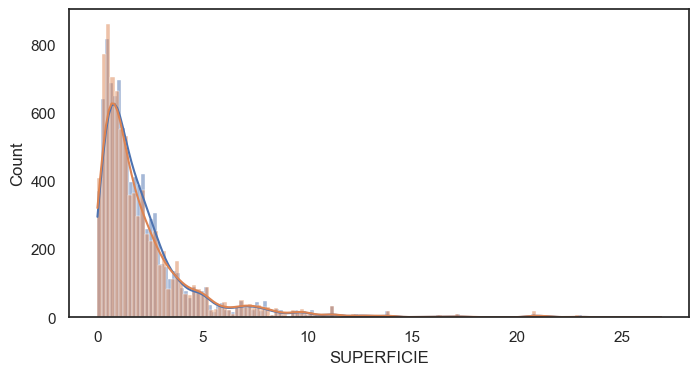

```python
grupos = TRAIN_SUPERFICIE.groupby('CAMPAÑA')

dataframes = {}
dataframes_final_regresionD = {}

for campaña, grupo in grupos:
    dataframes[campaña] = grupo.reset_index(level=0, drop=True)

for campaña, df in dataframes.items():

    datos_train_regresionD = df.copy(deep=True)
    columns = ['CAMPAÑA', 'ID_FINCA', 'ID_ZONA', 'ID_ESTACION', 'ALTITUD', 'VARIEDAD', 'MODO', 'TIPO', 'COLOR','SUPERFICIE']

    training_data = datos_train_regresionD[datos_train_regresionD['SUPERFICIE'].notnull()][columns]
    test_data = datos_train_regresionD[datos_train_regresionD['SUPERFICIE'].isnull()][columns]

    X_train = training_data.drop('SUPERFICIE', axis=1)
    y_train = training_data['SUPERFICIE']
    X_test = test_data.drop('SUPERFICIE', axis=1)

    model = LinearRegression()
    model.fit(X = X_train, y = y_train)

    predicted_values = model.predict(X_test)
    predicted_values = np.maximum(predicted_values, 0.00072)
    datos_train_regresionD.loc[datos_train_regresionD['SUPERFICIE'].isnull(), 'SUPERFICIE'] = predicted_values

    dataframes_final_regresionD[campaña] = datos_train_regresionD

TRAIN_FINAL_REGRESIOND = pd.concat(dataframes_final_regresionD.values(), ignore_index=True)

plt.figure(figsize=(8,4))
sns.histplot(x=TRAIN_FINAL_REGRESIOND['SUPERFICIE'], kde=True)
sns.histplot(x=TRAIN_SUPERFICIE['SUPERFICIE'], kde=True);
```

```python
sns.heatmap(TRAIN_FINAL_REGRESIOND[['SUPERFICIE']].isnull(), cbar=False);
```

Stochastic Regression Imputation

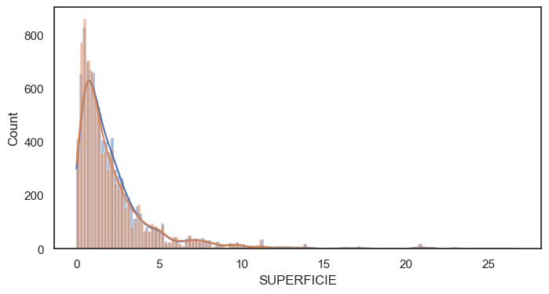

```python
grupos = TRAIN_SUPERFICIE.groupby('CAMPAÑA')

dataframes = {}
dataframes_final_regresionS = {}

for campaña, grupo in grupos:
    dataframes[campaña] = grupo.reset_index(level=0, drop=True)

for campaña, df in dataframes.items():
    datos_train_regresionS = df.copy(deep=True)
    columns = ['CAMPAÑA', 'ID_FINCA', 'ID_ZONA', 'ID_ESTACION', 'ALTITUD', 'VARIEDAD', 'MODO', 'TIPO', 'COLOR','SUPERFICIE']

    training_data = datos_train_regresionS[datos_train_regresionS['SUPERFICIE'].notnull()][columns]
    test_data = datos_train_regresionS[datos_train_regresionS['SUPERFICIE'].isnull()][columns]

    X_train = training_data.drop('SUPERFICIE', axis=1)
    y_train = training_data['SUPERFICIE']
    X_test = test_data.drop('SUPERFICIE', axis=1)

    model = LinearRegression()
    model.fit(X = X_train, y = y_train)

    num_predictions = 10
    stochastic_predictions = np.empty((num_predictions, len(test_data)))
    for i in range(num_predictions):
        stochastic_predictions[i] = model.predict(X_test) + np.random.normal(0, 1, len(test_data))

    imputed_values = np.mean(stochastic_predictions, axis=0)
    imputed_values = np.maximum(imputed_values, 0.00072)

    datos_train_regresionS.loc[datos_train_regresionS['SUPERFICIE'].isnull(), 'SUPERFICIE'] = imputed_values
    dataframes_final_regresionS[campaña] = datos_train_regresionS

TRAIN_FINAL_REGRESIONS = pd.concat(dataframes_final_regresionS.values(), ignore_index=True)

plt.figure(figsize=(8,4))
sns.histplot(x=TRAIN_FINAL_REGRESIONS['SUPERFICIE'], kde=True)
sns.histplot(x=TRAIN_SUPERFICIE['SUPERFICIE'], kde=True);
```

```python
sns.heatmap(TRAIN_FINAL_REGRESIONS[['SUPERFICIE']].isnull(), cbar=False);
```

After several tests, we selected Stochastic Regression Imputation as the best

```python
TRAIN_COMPLETO = TRAIN_FINAL_REGRESIONS.copy(deep=True)
TRAIN_COMPLETO
```

|  | CAMPAÑA | ID_FINCA | ID_ZONA | ID_ESTACION | ALTITUD | VARIEDAD | MODO | TIPO | COLOR | SUPERFICIE | PRODUCCION |
| --- | --- | --- | --- | --- | --- | --- | --- | --- | --- | --- | --- |
| 0 | 14 | 76953 | 515 | 4 | 660.0 | 26 | 2 | 0 | 1 | 3.349317 | 22215.0 |
| 1 | 14 | 84318 | 515 | 4 | 660.0 | 26 | 2 | 0 | 1 | 2.634635 | 22215.0 |
| 2 | 14 | 85579 | 340 | 4 | 520.0 | 32 | 2 | 0 | 1 | 1.688062 | 20978.0 |
| 3 | 14 | 69671 | 340 | 4 | 520.0 | 32 | 2 | 0 | 1 | 1.974094 | 40722.0 |
| 4 | 14 | 14001 | 852 | 14 | 650.0 | 81 | 1 | 0 | 1 | 3.105389 | 14126.0 |
| ... | ... | ... | ... | ... | ... | ... | ... | ... | ... | ... | ... |
| 9596 | 22 | 37461 | 239 | 6 | 700.0 | 52 | 2 | 0 | 1 | 3.680000 | NaN |
| 9597 | 22 | 58769 | 239 | 6 | 700.0 | 32 | 2 | 0 | 1 | 4.250000 | NaN |
| 9598 | 22 | 58769 | 239 | 6 | 700.0 | 59 | 2 | 0 | 1 | 4.070000 | NaN |
| 9599 | 22 | 88928 | 239 | 6 | 700.0 | 40 | 2 | 0 | 1 | 4.572700 | NaN |
| 9600 | 22 | 88928 | 239 | 6 | 700.0 | 52 | 2 | 0 | 1 | 1.609900 | NaN |

9601 rows × 11 columns

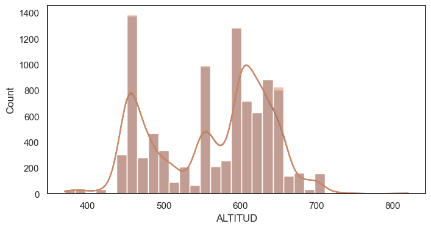

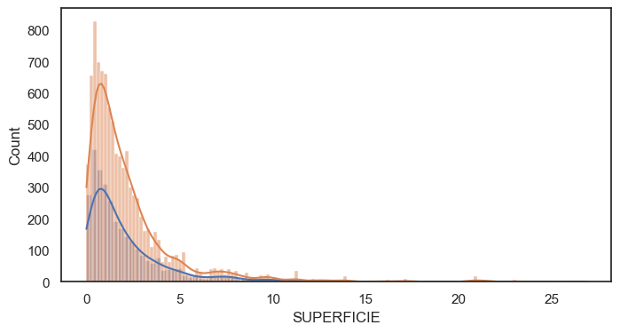

```python
for col in ['ALTITUD', 'SUPERFICIE']:
    plt.figure(figsize=(8,4))
    sns.histplot(x=TRAIN[col], kde=True)
    sns.histplot(x=TRAIN_COMPLETO[col], kde=True)
    plt.show()
```

```python
TRAIN_COMPLETO.to_csv('./Datos_Completos/UH_2023_TRAIN_FINAL.csv', index=None)
```